# Exploring Ford GoBike System Data

## by Duyen Nguyen

## Investigation Overview

The Ford GoBike (now Bay Wheels) System Datasets include data about trip duration, time of departure and arrival, starting point and destination as well as user-related data like gender, birth year, etc. of the Bay Wheels bikeshare program offered by Lyft in Bay Area. Datasets ranging from June 2017 to September 2019 were obtained from [Lyft's official website](https://www.lyft.com/bikes/bay-wheels/system-data). The main interest in exploring this dataset is finding out how trip duration changes based on each day of the week, month and year. Another point of interest is the volume of trips taken each day, month and year. I would also like to determine whether user types, gender and age have any effect on trip duration.

## Dataset Overview

The dataset contains data for 4,256,681 anonymized trips with attributes including bike ID, start time, end time, duration of trip in seconds; ID, name, longitude, latitude of start station and end station; user information i.e. birth year, gender, user type, rental access method and whether user belongs to the Bike Share for All program.

There are two user types: Subscriber and Customer. User's genders include 'Male', 'Female' and 'Other'. Users can access the rental bikeshare program via the Lyft app or their own Clipper card.

## Distribution of trip duration (secconds)

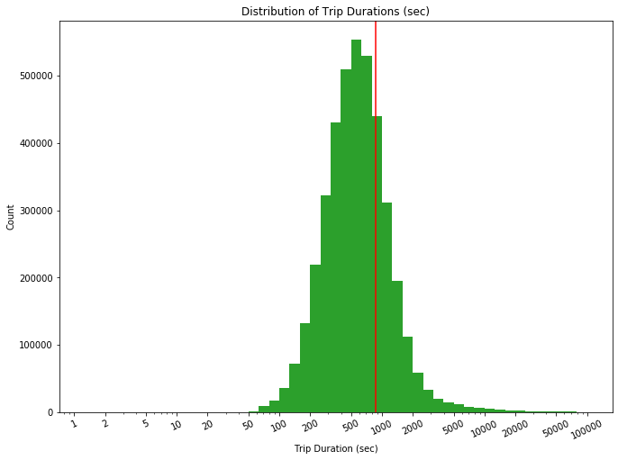

```python
plt.figure(figsize=[11, 8])
color = sb.color_palette()[2]
bin_edges = 10 ** np.arange(0.1, np.log10(df['duration_sec'].max())+0.1, 0.1)
plt.hist(df['duration_sec'], bins=bin_edges, color=color);
x_ticks = [1, 2, 5, 10, 20, 50, 100, 200, 500, 1000, 2000, 5000, 10000, 20000, 50000, 100000]
plt.xscale('log')
plt.xticks(x_ticks, x_ticks, rotation=25);
plt.axvline(x=df['duration_sec'].mean(), color='red')
plt.xlabel('Trip Duration (sec)')
plt.ylabel('Count')
plt.title('Distribution of Trip Durations (sec)');
```

## Volume of trips in each year, month, day of the week and hour of the day

As the datasets obtained only started in June 2017, the number of trips taken in 2017 is significantly lower than those of 2018 and 2019, which are almost equal to each other. However, data in 2019 ends in September so it is safe to assume that the number of trips have been steadily increasing each year. Trip volume increases towards the summer months and peaks in September before sharply decreases towards the end of the year. This trend makes perfect sense due to the warmer summer weather that is optimal for biking, while the colder winter weather means users tend to opt for other forms of transportation.

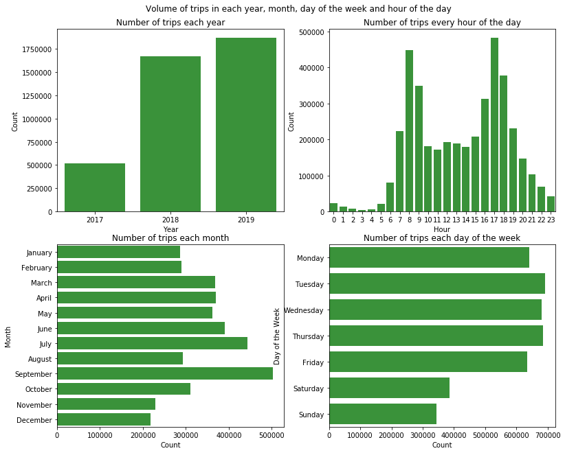

```python
#plot number of trips taken in each year, month, day of the week and hour of the day
fig = plt.figure(figsize=[13, 10])

plt.subplot(2, 2, 1)
sb.countplot(data=df, x='year', color=color)
plt.xlabel('Year')
plt.ylabel('Count')
plt.title('Number of trips each year')

plt.subplot(2, 2, 2)
sb.countplot(data=df, x='hour', color=color)
plt.xlabel('Hour')
plt.ylabel('Count')
plt.title('Number of trips every hour of the day')

plt.subplot(2, 2, 3)
sb.countplot(data=df, y='month', color=color)
plt.xlabel('Count')
plt.ylabel('Month')
plt.title('Number of trips each month')

plt.subplot(2, 2, 4)
sb.countplot(data=df, y='day_of_the_week', color=color)
plt.xlabel('Count')
plt.ylabel('Day of the Week')
plt.title('Number of trips each day of the week');

plt.subplots_adjust(top=0.93, hspace = 0.18);
fig.suptitle('Volume of trips in each year, month, day of the week and hour of the day');
```

## Changes in trip duration by year, month and day of the week

> The average trip duration remain relatively the same over the years. During each year, trips tend to be longer during the summer months. On a daily scale, weekend trips are significantly longer than weekday trips. This could signify the difference in purpose as weekday trips are potentially more task-oriented while weekend trips can be more leisure-oriented.

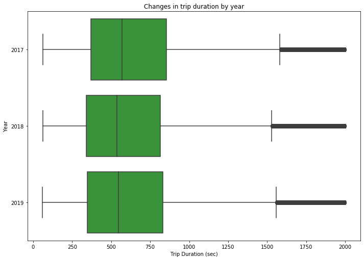

```python
#Box plots showing how duration varies each year, month and day of the week
duration_majority = df[df.duration_sec <= 2000]
plt.figure(figsize=[11.69, 8.27])
sb.boxplot(data=duration_majority, y='year', x='duration_sec', color=color)
plt.ylabel('Year')
plt.xlabel('Trip Duration (sec)')
plt.title('Changes in trip duration by year');
```

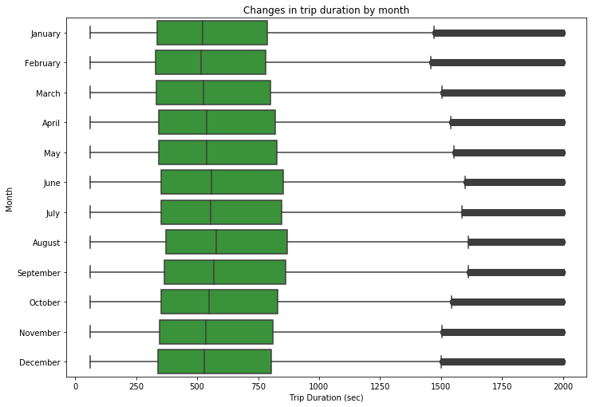

```python
plt.figure(figsize=[11.69, 8.27])
sb.boxplot(data=duration_majority, y='month', x='duration_sec', color=color)
plt.ylabel('Month')
plt.xlabel('Trip Duration (sec)')
plt.title('Changes in trip duration by month');
```

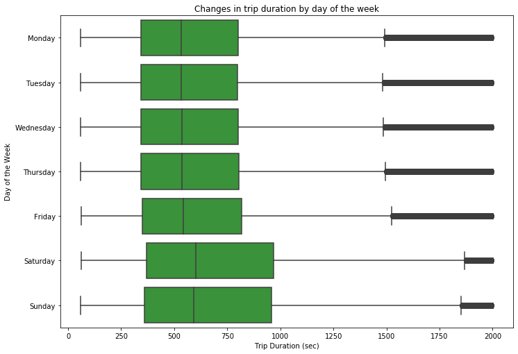

```python
plt.figure(figsize=[11.69, 8.27])
sb.boxplot(data=duration_majority, y='day_of_the_week', x='duration_sec', color=color)
plt.ylabel('Day of the Week')
plt.xlabel('Trip Duration (sec)')
plt.title('Changes in trip duration by day of the week');
```

## Maps of most frequented locations by the most used bike

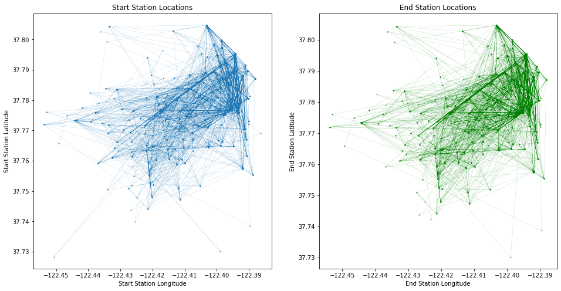

```python
bike_2692 = df[df.bike_id == '2692']

plt.figure(figsize=[16, 8])
plt.subplot(1, 2, 1)
plt.plot(bike_2692.start_station_longitude, bike_2692.start_station_latitude, marker='o', markersize=0.8,
         linestyle='dashed', linewidth=0.15)
plt.xlabel('Start Station Longitude')
plt.ylabel('Start Station Latitude')
plt.title('Start Station Locations');

plt.subplot(1, 2, 2)
plt.plot(bike_2692.end_station_longitude, bike_2692.end_station_latitude, marker='o', markersize=0.8,
         linestyle='dashed', color='green', linewidth=0.15)
plt.xlabel('End Station Longitude')
plt.ylabel('End Station Latitude')
plt.title('End Station Locations');
```

## Trip duration vs. number of trips on a weekly basis

> It seems like on a weekly basis, number of trips and average duration of trips are potentially inversely correlated to each other. First, let's look at changes of trip duration over the course of a week for each month.

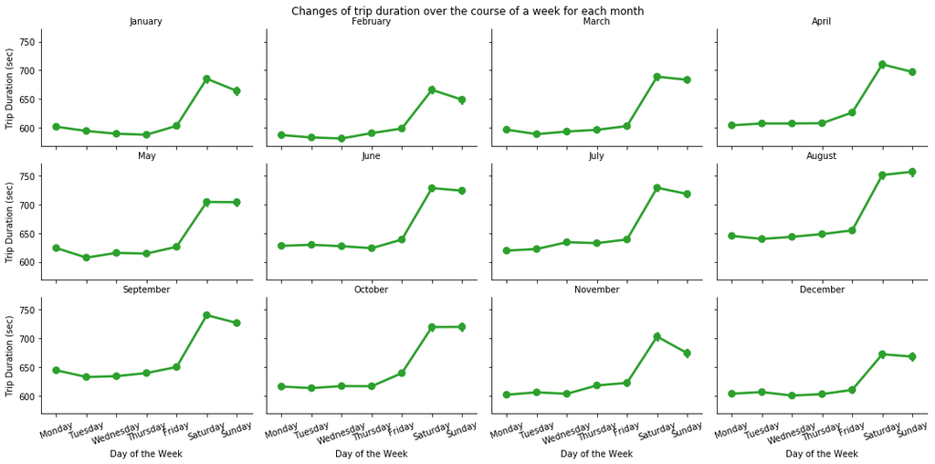

```python
mpl.rcParams.update({'font.size': 10})
day_ticks = ['Monday', 'Tuesday', 'Wednesday', 'Thursday', 'Friday', 'Saturday', 'Sunday']
g = sb.FacetGrid(data = duration_majority, col = 'month', col_wrap = 4, height = 2.5, aspect=1.5).set_xticklabels(day_ticks, rotation=20);
g.map(sb.pointplot, 'day_of_the_week', 'duration_sec', color=color);
g.set_xlabels('Day of the Week')
g.set_ylabels('Trip Duration (sec)')
g.set_titles('{col_name}');
plt.subplots_adjust(top=0.93, hspace = 0.15);
g.fig.suptitle('Changes of trip duration over the course of a week for each month');
```

Now, let's look at changes in number of trips over the course of a week for each month.

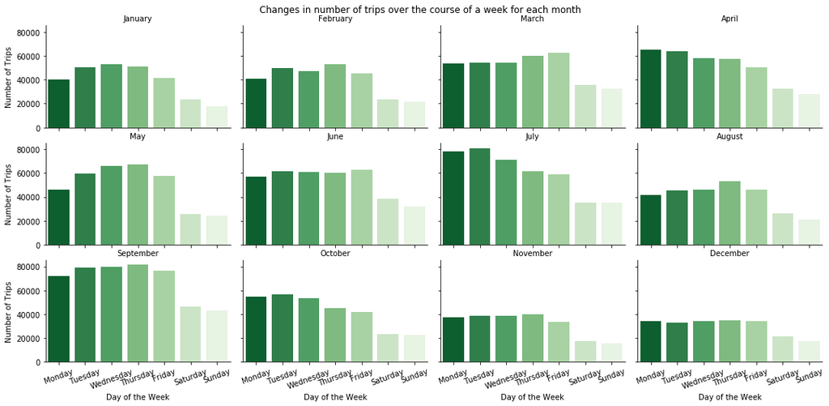

```python
g = sb.FacetGrid(data = duration_majority, col = 'month', col_wrap = 4, height = 2.5, aspect=1.5)
g.set_xticklabels(day_ticks, rotation=20)
g.map(sb.countplot, 'day_of_the_week', palette='Greens_r')
g.set_xlabels('Day of the Week')
g.set_ylabels('Number of Trips')
g.set_titles(col_template='{col_name}')
plt.subplots_adjust(top=0.93, hspace = 0.15)
g.fig.suptitle('Changes in number of trips over the course of a week for each month');
```

As observed in the previous two plots, average duration of trips tend to vary slightly at the beginning of the week and steadily increases towards the weekend. Meanwhile, number of trips on each day sees the opposite trend, decreasing slightly on Friday, significantly on Saturday and hitting bottom on Sunday. We can see this relationship clearer in a scatterplot.

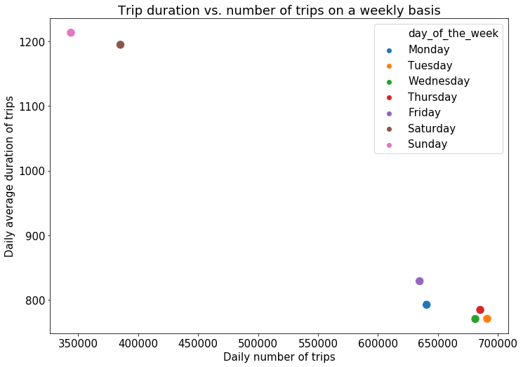

```python
#create new dataframe and plot for relationship between duration and volume in each week
day_count = df.groupby(['day_of_the_week'])['day_of_the_week'].count().values
daily_duration = df.groupby(['day_of_the_week'])['duration_sec'].mean().values
day_of_the_week = ['Monday', 'Tuesday', 'Wednesday', 'Thursday', 'Friday', 'Saturday', 'Sunday']
d = {'day_count':day_count, 'daily_duration':daily_duration, 'day_of_the_week':day_of_the_week}
data = pd.DataFrame(d)
#plot scatterplot for correlation between tripduration and number of trips during the week
mpl.rcParams.update({'font.size': 15});
plt.figure(figsize=[11.69, 8.27])
sb.scatterplot(data=data, x='day_count', y='daily_duration', hue='day_of_the_week', s=150)
plt.xlabel('Daily number of trips')
plt.ylabel('Daily average duration of trips')
plt.title('Trip duration vs. number of trips on a weekly basis');
```